# Covid-19 outbreak in Mexico

AS2019354 W.S.Y.S Fonseka

10/5/2022

## **Mexico**

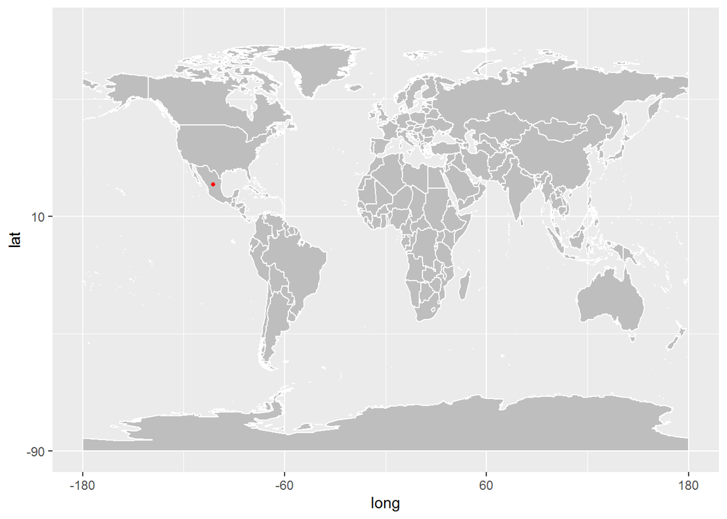

Mexico, country of southern North America and the third largest country in Latin America, after Brazil and Argentina. Mexican society is characterized by extremes of wealth and poverty, with a limited middle class wedged between an elite cadre of landowners and investors on the one hand and masses of rural and urban poor on the other. But in spite of the challenges it faces as a developing country, Mexico is one of the chief economic and political forces in Latin America. It has a dynamic industrial base, vast mineral resources, a wide-ranging service sector, and the world’s largest population of Spanish speakers—about two and a half times that of Spain or Colombia. As its official name suggests, the Estados Unidos Mexicanos (United Mexican States) incorporates 31 socially and physically diverse states and the Federal District.

## Lockdown status in Mexico

As of October 2nd, 2022, Quintana Roo is currently averaging approximately 7 new Covid case a day in a state with a population of 1.85+ million. Each state in Mexico is assigned one of four colors (green, yellow, orange, red) based on current rates of infection and hospital occupancy. The status of Quintana Roo (Cancun, Tulum, Cozumel, etc.) is currently GREEN meaning lower risk. Case numbers in the islands of Cozumel, Isla Mujeres and Holbox are still low. As of October 2nd, hospital occupancy is currently 0% full in Cancun, 0% full in Isla Mujeres, 0% in Cozumel, 0% in Playa del Carmen and 0% in Tulum. Hospitalizations continue to stay low and the majority of locals are now vaccinated.

## Government actions against Corona pandemic

On March 19th, the EU Central Bank opened a ‘swap’ mechanism with its counterparty from Mexico for $60,000 million of US dollars to provide liquidity in dollars for at least 6 months. On March 30th, Mexican government published on the official gazette the agreement in which “Sanitary Emergency due to Act of God” is declared due to the pandemic derived from the virus known as SARS-CoV 2 (COVID-19).Mexican government has announced that it will be granted one million loans of MXN 25,000 each one. 500,000 for the informal economy and 500,000 for the formal economy.On May 14, 2020, the government of Mexico, issued a decree through the official Gazette which establishes that as part of the strategy for the reopening of activities, an epidemiological traffic light system would be used by regions.

## Exploratory Data analysis

### Death cases in Mexico

```
##         date province country     lat      long  type cases uid iso2 iso3 code3
## 1 2020-01-22     <NA>  Mexico 23.6345 -102.5528 death     0 484   MX  MEX   484
## 2 2020-01-23     <NA>  Mexico 23.6345 -102.5528 death     0 484   MX  MEX   484
## 3 2020-01-24     <NA>  Mexico 23.6345 -102.5528 death     0 484   MX  MEX   484
## 4 2020-01-25     <NA>  Mexico 23.6345 -102.5528 death     0 484   MX  MEX   484
## 5 2020-01-26     <NA>  Mexico 23.6345 -102.5528 death     0 484   MX  MEX   484
## 6 2020-01-27     <NA>  Mexico 23.6345 -102.5528 death     0 484   MX  MEX   484
##   combined_key population continent_name continent_code
## 1       Mexico  127792286  North America             NA
## 2       Mexico  127792286  North America             NA
## 3       Mexico  127792286  North America             NA
## 4       Mexico  127792286  North America             NA
## 5       Mexico  127792286  North America             NA
## 6       Mexico  127792286  North America             NA
```

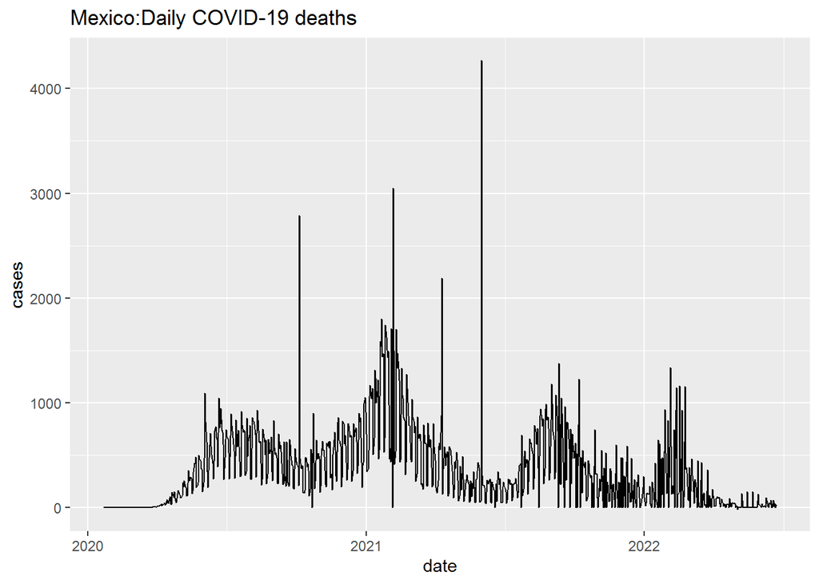

```
## [1] 368.198
```

### Confirmed cases in Mexico

```
##         date province country     lat      long      type cases uid iso2 iso3
## 1 2020-01-22     <NA>  Mexico 23.6345 -102.5528 confirmed     0 484   MX  MEX
## 2 2020-01-23     <NA>  Mexico 23.6345 -102.5528 confirmed     0 484   MX  MEX
## 3 2020-01-24     <NA>  Mexico 23.6345 -102.5528 confirmed     0 484   MX  MEX
## 4 2020-01-25     <NA>  Mexico 23.6345 -102.5528 confirmed     0 484   MX  MEX
## 5 2020-01-26     <NA>  Mexico 23.6345 -102.5528 confirmed     0 484   MX  MEX
## 6 2020-01-27     <NA>  Mexico 23.6345 -102.5528 confirmed     0 484   MX  MEX
##   code3 combined_key population continent_name continent_code
## 1   484       Mexico  127792286  North America             NA
## 2   484       Mexico  127792286  North America             NA
## 3   484       Mexico  127792286  North America             NA
## 4   484       Mexico  127792286  North America             NA
## 5   484       Mexico  127792286  North America             NA
## 6   484       Mexico  127792286  North America             NA
```

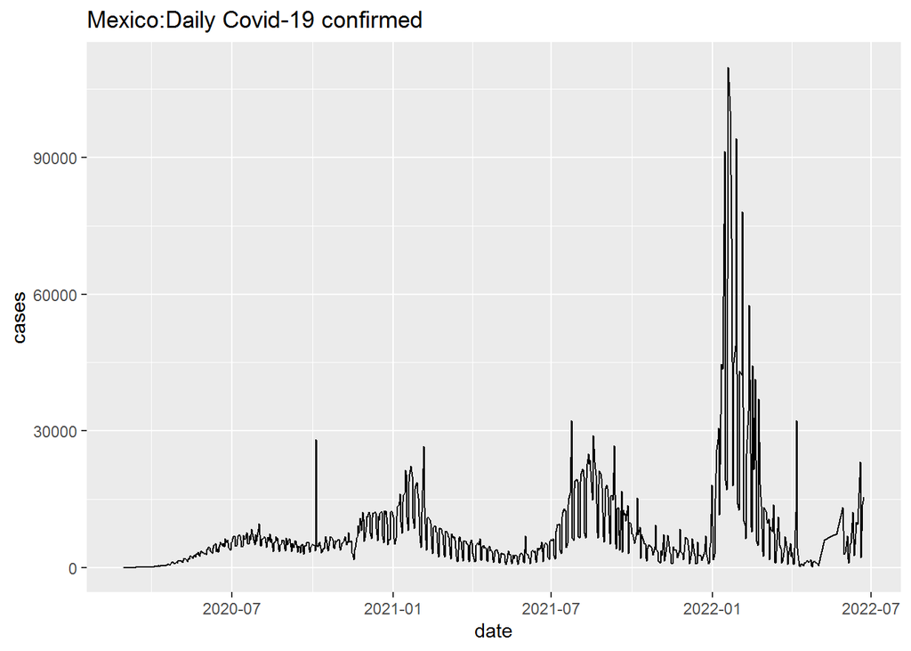

```
## [1] 7752.432
```

## Recovered cases in Mexico

```
##         date province country     lat      long     type cases uid iso2 iso3
## 1 2020-01-22     <NA>  Mexico 23.6345 -102.5528 recovery     0 484   MX  MEX
## 2 2020-01-23     <NA>  Mexico 23.6345 -102.5528 recovery     0 484   MX  MEX
## 3 2020-01-24     <NA>  Mexico 23.6345 -102.5528 recovery     0 484   MX  MEX
## 4 2020-01-25     <NA>  Mexico 23.6345 -102.5528 recovery     0 484   MX  MEX
## 5 2020-01-26     <NA>  Mexico 23.6345 -102.5528 recovery     0 484   MX  MEX
## 6 2020-01-27     <NA>  Mexico 23.6345 -102.5528 recovery     0 484   MX  MEX
##   code3 combined_key population continent_name continent_code
## 1   484       Mexico  127792286  North America             NA
## 2   484       Mexico  127792286  North America             NA
## 3   484       Mexico  127792286  North America             NA
## 4   484       Mexico  127792286  North America             NA
## 5   484       Mexico  127792286  North America             NA
## 6   484       Mexico  127792286  North America             NA
```

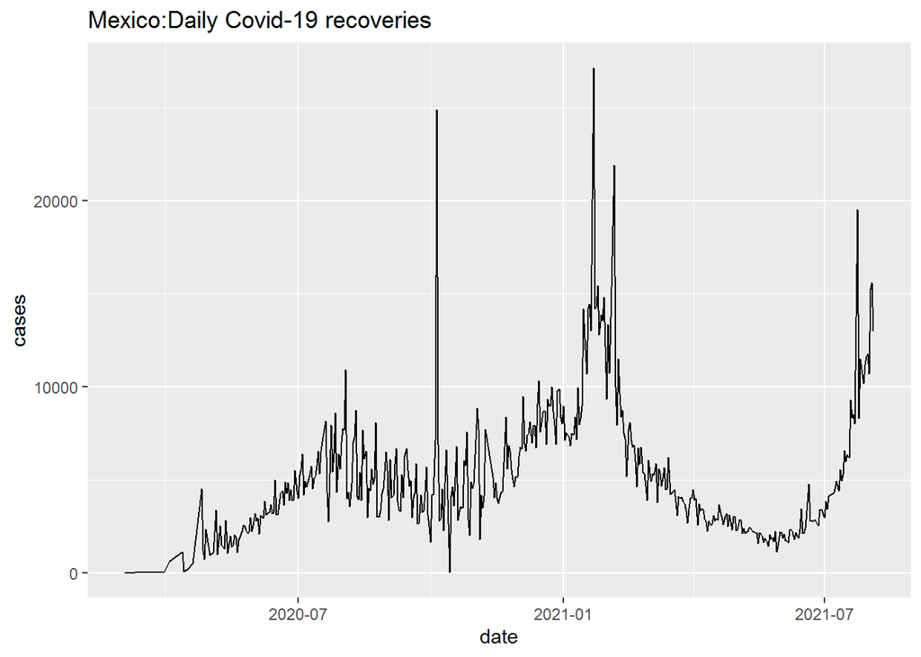

```
## [1] 5162.789
```

## Active cases

```
## # A tibble: 2,652 x 15
##    date       province country   lat  long type    cases   uid iso2  iso3  code3
##    <date>     <chr>    <chr>   <dbl> <dbl> <chr>   <int> <dbl> <chr> <chr> <dbl>
##  1 2020-01-22 <NA>     Mexico   23.6 -103. confir~     0   484 MX    MEX     484
##  2 2020-01-23 <NA>     Mexico   23.6 -103. confir~     0   484 MX    MEX     484
##  3 2020-01-24 <NA>     Mexico   23.6 -103. confir~     0   484 MX    MEX     484
##  4 2020-01-25 <NA>     Mexico   23.6 -103. confir~     0   484 MX    MEX     484
##  5 2020-01-26 <NA>     Mexico   23.6 -103. confir~     0   484 MX    MEX     484
##  6 2020-01-27 <NA>     Mexico   23.6 -103. confir~     0   484 MX    MEX     484
##  7 2020-01-28 <NA>     Mexico   23.6 -103. confir~     0   484 MX    MEX     484
##  8 2020-01-29 <NA>     Mexico   23.6 -103. confir~     0   484 MX    MEX     484
##  9 2020-01-30 <NA>     Mexico   23.6 -103. confir~     0   484 MX    MEX     484
## 10 2020-01-31 <NA>     Mexico   23.6 -103. confir~     0   484 MX    MEX     484
## # ... with 2,642 more rows, and 4 more variables: combined_key <chr>,
## #   population <dbl>, continent_name <chr>, continent_code <chr>
```

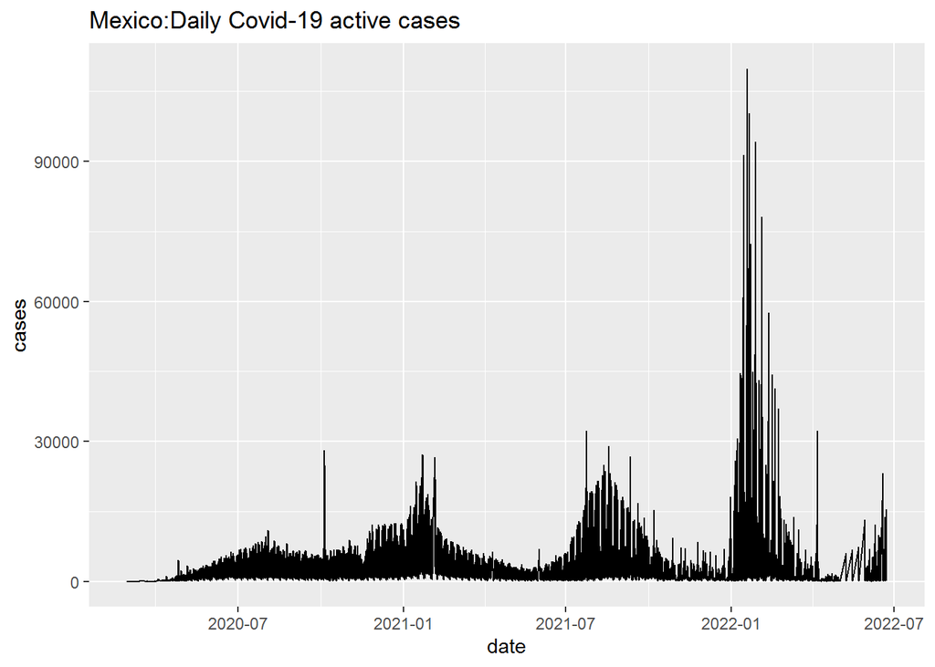

```
## [1] 4371.63
```

The mean number of active cases is 4371 and most active cases were seen at the beginning of 2022

## Comparison with other countries

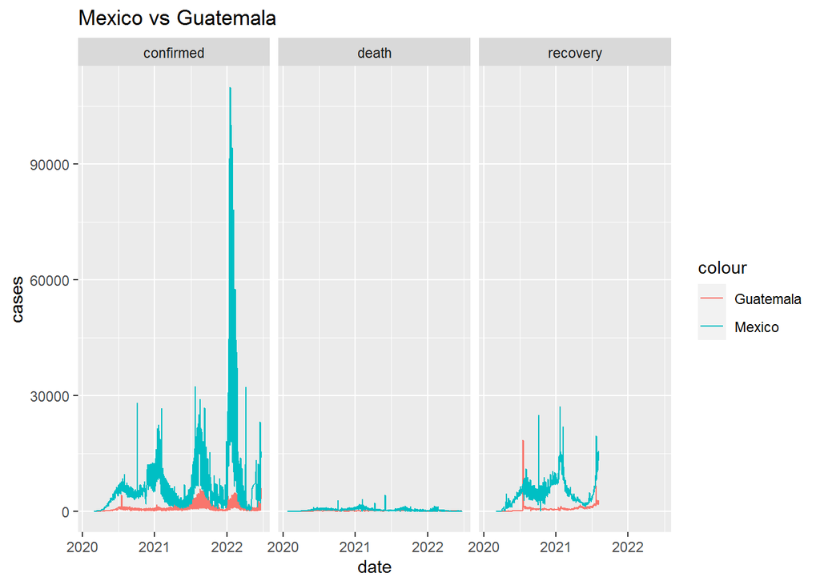

According to the charts , Mexico has shown high cases in every aspect.

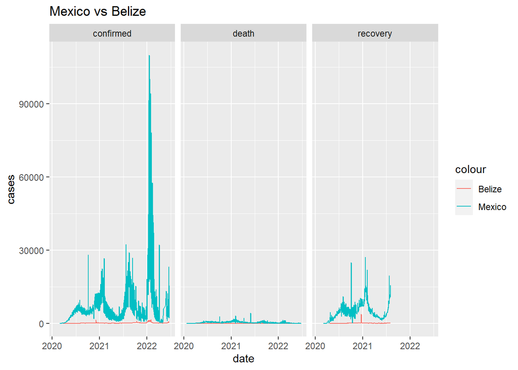

According to the charts , Mexico has shown high cases in every aspect.

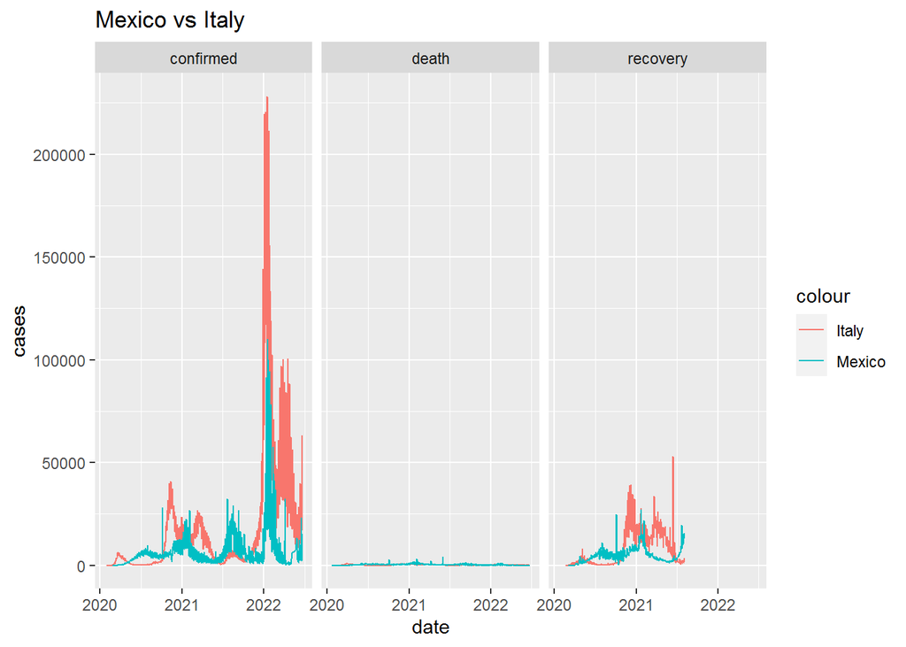

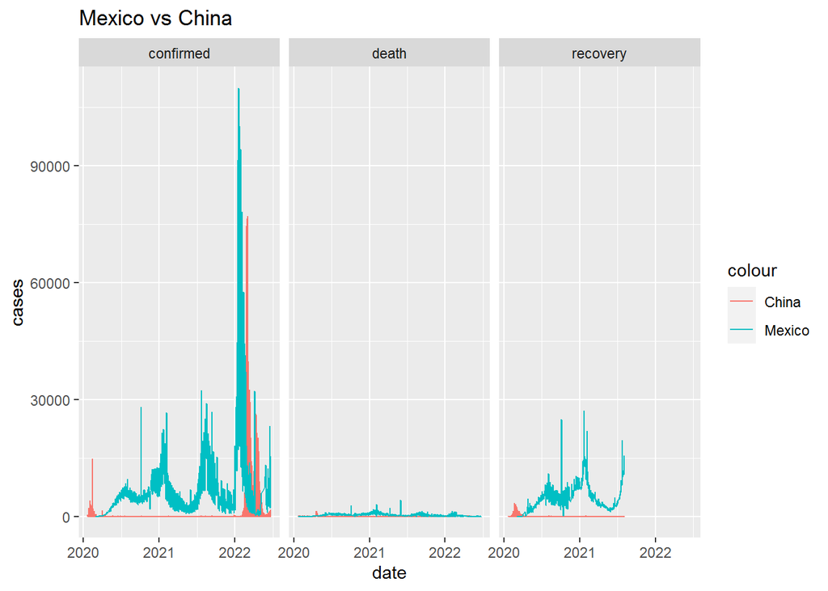

According to the charts , Mexico has shown high cases in every aspect.

## Conclusions and discussion

China had shown confirmed cases even before Mexico and they have also had recovery cases prior to Mexico too.

We cannot come to end conclusions since there are concerns that the Covid 19 death count is under reported in Mexico since only the deaths in hospitals.

## References

(1)Bernstein M.D,“Mexico”, https://www.britannica.com/countries_of_the_world

(2)Corona virus update for Mexico,https://www.islandlifemexico.com

(3)Covid in Mexico, https://www.bbc.com